# Your Digest for Tuesday, Sep 26, 2023 11:59 PM

**Any cause of _ventricular dysfunction**,_ including ischemic heart disease, dilated or *hypertrophic* cardiomyopathy, myocarditis, cor pulmonale, or acute valvular regurgitation, may qualify. **Myocardial ischemia without ventricular dysfunction or volume overload is not a cause of an S3.** The presence of an S3 is the most sensitive indicator of ventricular dysfunction.

- it may be due to heart muscle striking the chest wall.

> [!TIP] S3 - lose and early, S4 - Stiff and late.  
> S3 - compliant ventricle, early diastole (occurs in volume overload)  
> S4 - stiff ventricle, late diastole.

## Simplified pathogenesis

**TNF-alpha** and **IFN-alpha** and **IL-23** produced by the innate immune system's antigen presenting cells have major roles in psoriasis pathogenesis.  
IL-17 comes from Th17 cells.

- *Subungual hyperkeratosis* -> which leads to **onycholysis**
- splinter haemorrhages (is a recognized sign)
- Beau's lines (transverse line's arising from transient arrest of nail growth)

## Triggers for psoriasis:

- Certain drugs:
  - #2021GM-JUL/Q34
  - Most common ones are : beta blockers, lithium, antimalarial drugs, NSAIDS and tetracyclines.
  - TNF inhibitors can paradoxically cause exacerbations of psoriasis.

## Joint involvement in psoriasis

- Topical vitamin D analogs - used in combination with local corticosteroid. (**Calcipotriene** -> *hypoproliferative* effect on keratinocytes)
- Tar - time honored treatment; mechanism unknown. May be *anti-inflammatory* and *antiproliferative*.
- Calcineurin inhibitors - **topical tacrolimus**
  - Mechanism: **antiproliferative** effects and induced *apoptosis of T cells* within plaques.
- **Methotrexate** -> antiproliferative effects and immunosuppressive effects (good for psoriatic arthritis and nail psoriasis as well)
- **Acitretin** -> systemic retinoids; for **severe psoriasis**
- **Cylosporin** -> *T cell suppressor*
- TNF alpha inhibitors (*etanercept* and *infliximab*)

Irregularly irregular pulse

> This is due to better diastolic filling secondary to slower heart rate and better atrial contractility  
> If background of *Mitral stenosis*-> more resistance through MV -> more dependence of AV synchrony for ventricular filling -> *significant worsening of HF* when AF occurs.

Most effective startegy depends on how long AF has been going on = how likely is it to respond to rhythm control

- Rhythm control improves haemodynamics.
- *Both strategies have equal thromboembolic risk.*
- RACE and AFFIRM trials do not show conclusive evidence that either strategy has net mortality or symptoms benefit. (rate control *may even be better*)
- Antiarrhythmics used in rhythm control can be **proarrhythmogenic** specially in older patients.

## Localization ischemia of ST elevation MI

See: [[2023-SEMPaper#Coronary territories]]

> [!INFO] Only ST elevations can be localized  
> ST depressions cannot be localized. [Source](https://ecgwaves.com/ischemic-changes-in-the-st-segment-and-t-wave/)

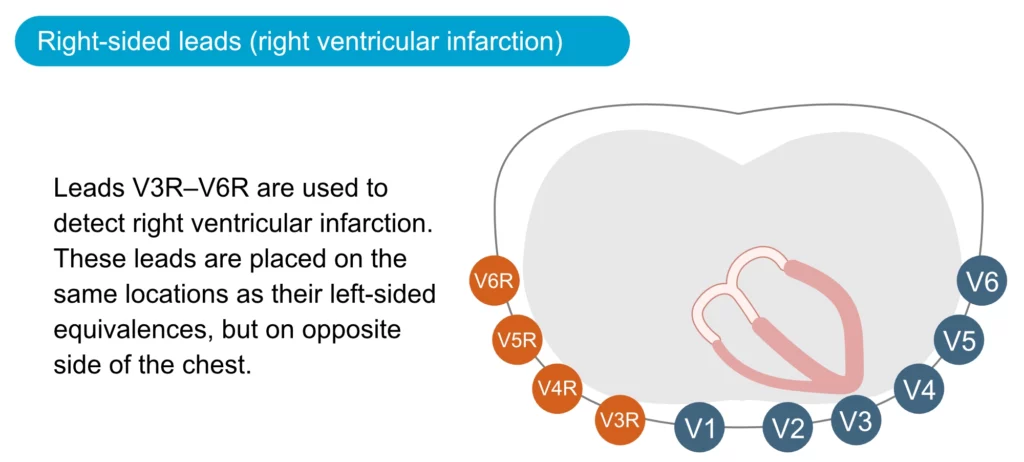

> [!WARNING] V5 and V6 are lateral leads  
> V5-V6 - **most sources say V5-V6 look at the lateral wall +/- anterior wall**. Not the apex as mentioned below.  
> But other sources like the Malaysian Clinical practice guideline [Source](https://www.researchgate.net/publication/335675881_Management_of_Acute_ST-Elevation_Myocardial_Infarction_Malaysia_Clinical_Practice_Guideline_MCPG_4th_Edition) agree with the table below

| Leads with ST segment elevations | Affected myocardial area | Occluded coronary artery (cuprit) |
| --- | --- | --- |
| V1–V2 | Septal | Proximal LAD. |
| V3–V4 | Anterior | LAD. |
| V5–V6 | Apical | Distal LAD, LCx or RCA. |
| I, aVL | Lateral | LCx. |
| II, aVF, III | Inferior | 90% RCA. 10% LCx. |
| V7, V8, V9 (reciprocal ST dips. frequently seen in V1–V3) | Posterolateral (also referred to as inferobasal or **posterior**) | RCA or LCx. |
| [Source](https://ecgwaves.com/topic/localization-localize-myocardial-infarction-ischemia-coronary-artery-occlusion-culprit-stemi/) |  |  |

> **V1-V2** (“septal leads”): primarily observes the ventricular septum, but may occasionally display ECG changes originating from the right ventricle. *Note that none of the leads in the 12-lead ECG are adequate to detect vectors of the right ventricle*. [Source](https://ecgwaves.com/topic/ekg-ecg-leads-electrodes-systems-limb-chest-precordial/)

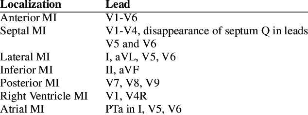

[Source](https://www.researchgate.net/figure/The-localizations-of-Myocardial-Infarction-20-Those-localizations-commonly-appear-with_tbl1_334667421)

> [!INFO] The septal Q wave  
> The septum normally depolorizes from left to right; this causes Q waves in V5 and V6.

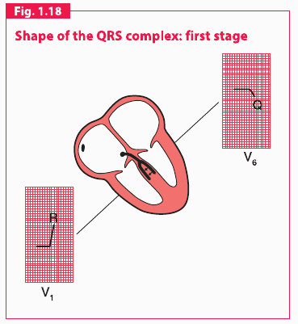

## Which part of the heart is 'posterior'?

[Source](https://www.ahajournals.org/doi/10.1161/circulationaha.106.624924#FIG1178548)  
This article confirms that there is some confusion about which part of heart is the 'posterior' part.  
Overall, it's the most posterior part of the wall in contact with the diaphragm.  
That's segment 4 in the bull's-eye representation of the heart. (?used in CT)

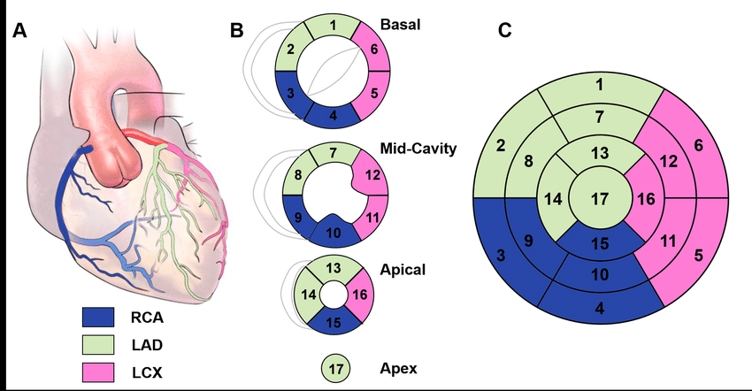

What artery is inolved? See table above.

## ECG changes in posterior MI

#2021GM-JUL/Q33

## Renal impairment in gout:

Two main mechanisms : nephrolithiasis and chronic urate nephropathy;  
So management of gout with concurrent renal impairment is a clinical issue.

## Treatment

### Treatment of acute flares:

- NSAIDS - very effective but contraindicated in renal impairment.
- If NSAIDs can't be used, colchicine is effective.
- Colchicine - alternative to NSAIDS. Inhibits neutrophil microtubules, thereby impairing neutrophil migration into sites of inflammation.
- Corticosteroids - oral prednisolone or IM or intra-articular depot methylprednisolone.

### Control measures:

Goal is to lower and maintain urate levels < 360 micromol/L.

**Diet**: Important because it will reduce urate levels by 15%.

- reduce alcohol - specially beer, avoid high fructose foods (like soft drinks)
- Reduce total calorie and cholesterol intake.
- Avoid red meat, spinach.

**Urate lowering medication**

- First few episodes of gout are managed symptomatically as above.
- Urate lowering therapy is started when episodes become frequent and problematic.

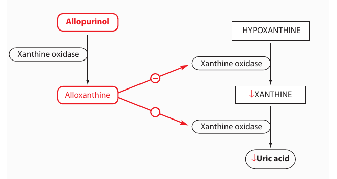

- **Allopurinol**:
  - Only when attacks are frequent and problematic or there is associated renal impairment. Side effects : GI disturbances, **blood dyscrasias** and **rashes**.
  - Xanthine oxidase inhibitors -> rapidly lowers urate levels.
  - (do not start within 6 months of an attack; acute lowering of serum urate concentration can itself trigger gout episodes).
- **Febuxostat**: as effective as allopurinol but overall associated with higher all cause mortality! 😲
  - Therefore, second line drug when allopurinol isn't tolerated.
- **Pegloticase**:
  - Given IV for severe gout.
- Uricosuric agents:
  - Probenecid - avoid in renal impairment
- Losartan -
  - Also has uricorusic properties.
- Targeted therapies:
  - Anakinra - IL-1 inhibitor; very expensive.
  - canakinumab - IL-1beta inhibitor.

## Chronic tophaceous gout

Persistent inflammation.  
Skin and periarticular urate crystal deposits (tophi) causing chronic pain and overlying skin ulceration.  
Punched out bone cysts on X ray.  
Urate nephropathy with renal impairment.  
Treatment:

- It's associated with chronic diuretic use -> stop or change diuretics.
- allopurinol
- pegloticase (especially in chemotherapy)

**Supply of the sinoatrial node**:

- In 60%, supplied by the right coronary artery.
- In 40%, supplied by the left coronary artery.

About 10% : left dominant

## Contraindications

> **Sacubitril-valsartan** and **AND** **ACE inhibitors** **can cause angioedema** via their inhibitory effect on the kallikrein system, which increases bradykinin. Both are **contraindicated** if the patient has a history of angiooedema of any cause.  
> Both are contraindicated in pregnancy due to teratogenicity.

> [!TIP] Mnemonic RBMS

**ACEi** (and other RAAS system blockers)

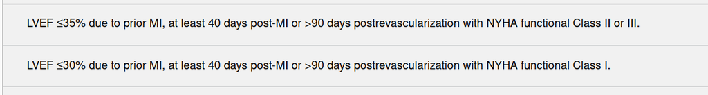

  [Source](https://www.ahajournals.org/doi/10.1161/CIRCRESAHA.118.313571#T3)

While the criteria above apply for MI induced heart failure, **non-ischaemic dilated cardiomyopathy** with heart failure is also **managed with ICD therapy** because **trials have shown benefits.**  
Source-UpToDate

## Cause of death in heart failure

Possible causes are

1. Progressive pump failure
2. Unexpected sudden cardiac death: usually from a ventricular arrhythmia
3. SCD in the setting of worsening heart failure.

> [!INFO] Mode of death in heart failure  
> Sudden cardiac death is commoner in NHYA II and III but worsening pump failure is the commonest in class IV.

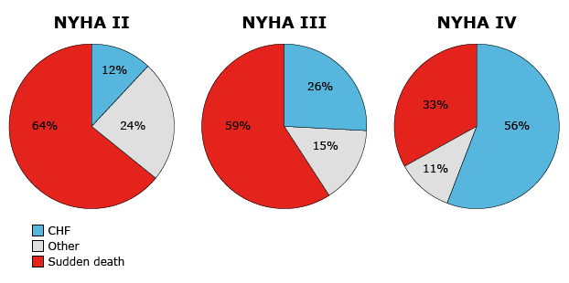